# O.4 Frontiers OXT

OXT and Psichological variables

Claudiu Papasteri

25 11 2019

# 1 Read and Merge

```r
#~~~~~~~~~~~~~~~~~~~~~~~~~~~~~~~~~~~~~~~~~~~~~~~~~~~~~~~~~~~~~~~~~~~~~~~~~~~~~~~~~~~~~~~~~~~~~~~~~~~~~~~~~~~~~~~~~~~~~~~~~~~~~~~~~~~~~~~~~~
# Read
#~~~~~~~~~~~~~~~~~~~~~~~~~~~~~~~~~~~~~~~~~~~~~~~~~~~~~~~~~~~~~~~~~~~~~~~~~~~~~~~~~~~~~~~~~~~~~~~~~~~~~~~~~~~~~~~~~~~~~~~~~~~~~~~~~~~~~~~~~~
wd <- "C:/Users/Mihai/Desktop/O.4 prealabil pt Frontiers/O.4 Date Psiho&OXT"
setwd(wd)

Data_OXT <- rio::import(file.path(wd, "\\OXT", "O.4 OXT Data.xlsx"))

Data_psih <- rio::import(file.path(wd, "\\Psiho", "DATE O4Cl 16.11.2019 procesat.xlsx"), which = "26martie2019")
Data_psih <- Data_psih[, c(1:6, 8:13)]

Data_Neo <- rio::import(file.path(wd, "\\Psiho", "DATE O4Cl 16.11.2019 procesat.xlsx"), which = "Neo scored")
Data_BDI <- rio::import(file.path(wd, "\\Psiho", "DATE O4Cl 16.11.2019 procesat.xlsx"), which = "BDI scored")
Data_STAI <- rio::import(file.path(wd, "\\Psiho", "DATE O4Cl 16.11.2019 procesat.xlsx"), which = "STAI scored")
```

```r
#~~~~~~~~~~~~~~~~~~~~~~~~~~~~~~~~~~~~~~~~~~~~~~~~~~~~~~~~~~~~~~~~~~~~~~~~~~~~~~~~~~~~~~~~~~~~~~~~~~~~~~~~~~~~~~~~~~~~~~~~~~~~~~~~~~~~~~~~~~
# Clean & Merge
#~~~~~~~~~~~~~~~~~~~~~~~~~~~~~~~~~~~~~~~~~~~~~~~~~~~~~~~~~~~~~~~~~~~~~~~~~~~~~~~~~~~~~~~~~~~~~~~~~~~~~~~~~~~~~~~~~~~~~~~~~~~~~~~~~~~~~~~~~~
Data_STAI <-
  Data_STAI %>%
  dplyr::filter(!is.na(ID)) %>%                                                                # no ID, no data
  dplyr::filter(rowSums(is.na(.)) < 2) %>%                                                     # filter out rows (no more than 1 NA on row)
  mutate(ID = stringr::str_replace(ID, "\\s", "|")) %>%                                        # replace first whitespace with | and use it to separate
  tidyr::separate(ID, into = c("ID", "Experim"), sep = "\\|") %>%                              # separate on only first whitespace that was replaced
  dplyr::select(-Experim)

Data_BDI <-
  Data_BDI %>%
  dplyr::filter(!is.na(ID)) %>%                                                                # no ID, no data
  dplyr::filter(rowSums(is.na(.)) < 1) %>%                                                     # filter out rows (not 1 NA)
  mutate(ID = stringr::str_replace(ID, "\\s", "|")) %>%                                        # replace first whitespace with | and use it to separate
  tidyr::separate(ID, into = c("ID", "Experim"), sep = "\\|") %>%                              # separate on only first whitespace that was replaced
  dplyr::select(-Experim)

Data_Neo <-
  Data_Neo %>%
  dplyr::filter(!is.na(ID)) %>%                                                                # no ID, no data
  dplyr::filter(rowSums(is.na(.)) < 6) %>%                                                     # filter out rows (no more than 5 NA on row)
  mutate(ID = stringr::str_replace(ID, "\\s", "|")) %>%                                        # replace first whitespace with | and use it to separate
  tidyr::separate(ID, into = c("ID", "Experim"), sep = "\\|") %>%                              # separate on only first whitespace that was replaced
  dplyr::select(-Experim)

Data_psih <-
  Data_psih %>%
  dplyr::filter(!is.na(ID)) %>%                                                                # no ID, no data
  dplyr::filter(rowSums(is.na(.)) < 8) %>%                                                     # filter out rows (no more than 7 NA on row)
  tidyr::separate(Conditia,  c("Nr_zi", "Conditia"), "\\s+") %>%                               # split on white space
  mutate(ID = stringr::str_replace(ID, "\\s", "|")) %>%                                        # replace first whitespace with | and use it to separate
  tidyr::separate(ID, into = c("ID", "Experim"), sep = "\\|") %>%                              # separate on only first whitespace that was replaced
  dplyr::rename("Nume" = Nume_Prenume) %>%
  dplyr::select(-Experim)

Data_OXT <-
  Data_OXT %>%
  tidyr::separate(ID,  c("ID", "Ziua", "Nr_zi", "Proba"), "\\s+") %>%                          # split on white space
  select(ID, Nr_zi, Proba, OXT) %>%
  tidyr::separate(ID, into = c("ID", "Experim"), sep = "\\/") %>%                              # separate on /
  dplyr::select(-Experim) %>%
  dplyr::rename("PrePost" = Proba) %>%
  mutate(PrePost = forcats::fct_recode(PrePost, "Pre" = "A", "Post" = "B")) %>%                # Proba A = Pre, B = Post on same day
  spread(key = PrePost, value = OXT) %>%
  dplyr::rename_at(vars(Pre, Post), ~ c("OXT_Pre", "OXT_Post"))


Data_merged <- dplyr::left_join(Data_psih, Data_OXT, by = c("ID", "Nr_zi"))                 # ID 40, 59 are incomplete in OXT -- dplyr::full_join


#~~~~~~~~~~~~~~~~~~~~~~~~~~~~~~~~~~~~~~~~~~~~~~~~~~~~~~~~~~~~~~~~~~~~~~~~~~~~~~~~~~~~~~~~~~~~~~~~~~~~~~~~~~~~~~~~~~~~~~~~~~~~~~~~~~~~~~~~~~
# Make Wide Dataframe of merged
#~~~~~~~~~~~~~~~~~~~~~~~~~~~~~~~~~~~~~~~~~~~~~~~~~~~~~~~~~~~~~~~~~~~~~~~~~~~~~~~~~~~~~~~~~~~~~~~~~~~~~~~~~~~~~~~~~~~~~~~~~~~~~~~~~~~~~~~~~~
# Check if ids have > 1 row of data (empty ID have only 1 row; thei have only 1 Condition)
# Careful! This function modfies the datasets in the global envinronment
delete_empty_id <- function(df){
  list_empty_id <-
    df %>%
    dplyr::group_by(ID) %>%
    dplyr::summarise(row_count = n()) %>%
    dplyr::rename("empty_id" = ID) %>%
    mutate(delete_id = if_else(row_count < 2, TRUE, FALSE)) %>%
    filter(delete_id == TRUE)

  df_modif <-
    df %>%
    filter(!ID %in% list_empty_id$empty_id)

  if(!identical(df, df_modif)){
    df <- deparse(substitute(df))
    cat("Deleting from ", print(as.name(df))); print(list_empty_id)                    # print out which ids are deleted from which dataset
    assign(df, df_modif, envir = globalenv())                                          # assign modified df to original dataset from Global
  }else cat("No empty datasets. Nothing to delete")
}
delete_empty_id(Data_merged)
```

Data_merged Deleting from Data_merged

| empty_id | row_count | delete_id |
| --- | --- | --- |
| 15 | 1 | TRUE |
| 36 | 1 | TRUE |
| 40 | 1 | TRUE |
| 46 | 1 | TRUE |
| 53 | 1 | TRUE |
| 59 | 1 | TRUE |
| 60 | 1 | TRUE |
| 62 | 1 | TRUE |
| 67 | 1 | TRUE |

```r
# Dataframe for regular analyses
Data_merged_wide <-
  Data_merged %>%
  select(-c(Varsta, Gen)) %>%            # exclude Gen, Varsta: merge after because it interferes with spread()
  gather("variable", "value", c(Data, Nr_zi, Vas_Stres_Pre:OXT_Post), -c(1:2)) %>%       # Conditia needs to be outside
  unite("united_var", c(variable, Conditia), sep = "_") %>%
  spread(united_var, value) %>%
  mutate_at(vars(5:22), list(~as.numeric(as.character(.))))

# sum(is.na(Data_merged[, 6:15])) == sum(is.na(Data_merged_wide[, 5:22]))    # check if nr of NA is the same after melt


# Full Wide Dataframe
Data_merged_wide_all <-
  Data_merged[, c("ID", "Nume", "Varsta", "Gen")] %>%                        # need to add these back, but just the main unduplicated row
  dplyr::distinct(ID, .keep_all = TRUE) %>%
    dplyr::left_join(., Data_merged_wide, by = "ID") %>%
    dplyr::rename("Nume" = Nume.x) %>%
    dplyr::select(-Nume.y) %>%
    dplyr::left_join(., Data_BDI, by = "ID") %>%
    dplyr::left_join(., Data_STAI, by = "ID") %>%
    dplyr::left_join(., Data_Neo, by = "ID") %>%
    mutate_at(vars(23:60), list(~as.numeric(as.character(.)))) %>%
    dplyr::arrange(ID)


# Full Long Dataframe
vars_OglEcran <- grep("OGL|ECRAN", colnames(Data_merged_wide_all))

Data_merged_long_all <-
  Data_merged_wide_all %>%
  gather(variable, value, vars_OglEcran, -c(ID)) %>%                                      # gather Data and Nr_zi as these are OglEcran level
  tidyr::separate(variable,  c("variable", "OglEcran"), "_(?=[^_]+$)") %>%                # split only on last "_"
  spread(variable, value) %>%
  rename_at(vars(vars_OglEcran), list(~stringr::str_remove_all(., c("_OGL|_ECRAN")))) %>%
  arrange(ID)

vars_PrePost <- grep("Pre|Post", colnames(Data_merged_long_all))

Data_merged_long_all <-
  Data_merged_long_all %>%
  pivot_longer(vars_PrePost, names_to = c(".value","PrePost"), names_pattern = "(.*)_(.*)") %>%     # magic
  mutate_at(vars(48:50), list(~as.numeric(as.character(.)))) %>%
  arrange(ID)
```

## 1.1 Dataset - Long Format

```r
Data_merged_long_all %>%
  dplyr::select(-Nume) %>%
    DT::datatable(
      extensions = 'Buttons',
      options = list(pageLength = 10,
                     scrollX='500px',
                     dom = 'Bfrtip',
                     buttons = c('excel', "csv")))
```

|  | ID | Varsta | Gen | ScorBDI | StaiSbrut | StaiTbrut | N | E | O | A | C | N1 | E1 | O1 | A1 | C1 | N2 | E2 | O2 | A2 | C2 | N3 | E3 | O3 | A3 | C3 | N4 | E4 | O4 | … |
| --- | --- | --- | --- | --- | --- | --- | --- | --- | --- | --- | --- | --- | --- | --- | --- | --- | --- | --- | --- | --- | --- | --- | --- | --- | --- | --- | --- | --- | --- | --- |
| 1 | 10 | 23 | m | 7 | 36 | 36 |  |  |  |  |  |  |  |  |  |  |  |  |  |  |  |  |  |  |  |  |  |  |  | … |
| 2 | 10 | 23 | m | 7 | 36 | 36 |  |  |  |  |  |  |  |  |  |  |  |  |  |  |  |  |  |  |  |  |  |  |  | … |
| 3 | 10 | 23 | m | 7 | 36 | 36 |  |  |  |  |  |  |  |  |  |  |  |  |  |  |  |  |  |  |  |  |  |  |  | … |
| 4 | 10 | 23 | m | 7 | 36 | 36 |  |  |  |  |  |  |  |  |  |  |  |  |  |  |  |  |  |  |  |  |  |  |  | … |
| 5 | 11 | 31 | m | 22 | 57 | 59 |  |  |  |  |  |  |  |  |  |  |  |  |  |  |  |  |  |  |  |  |  |  |  | … |
| 6 | 11 | 31 | m | 22 | 57 | 59 |  |  |  |  |  |  |  |  |  |  |  |  |  |  |  |  |  |  |  |  |  |  |  | … |
| 7 | 11 | 31 | m | 22 | 57 | 59 |  |  |  |  |  |  |  |  |  |  |  |  |  |  |  |  |  |  |  |  |  |  |  | … |
| 8 | 11 | 31 | m | 22 | 57 | 59 |  |  |  |  |  |  |  |  |  |  |  |  |  |  |  |  |  |  |  |  |  |  |  | … |
| 9 | 12 | 24 | f | 1 | 24 | 37 | 143 | 54 | 176 | 140 | 48 | 27 | 14 | 31 | 20 | 15 | 6 | 2 | 31 | 26 | 3 | 28 | 4 | 31 | 26 | 19 | 24 | 8 | 22 | … |
| 10 | 12 | 24 | f | 1 | 24 | 37 | 143 | 54 | 176 | 140 | 48 | 27 | 14 | 31 | 20 | 15 | 6 | 2 | 31 | 26 | 3 | 28 | 4 | 31 | 26 | 19 | 24 | 8 | 22 | … |

[output cut: 218 more lines]

## 1.2 Dataset - Wide Format

```r
Data_merged_wide_all %>%
  dplyr::select(-Nume) %>%
    DT::datatable(
      extensions = 'Buttons',
      options = list(pageLength = 10,
                     scrollX='500px',
                     dom = 'Bfrtip',
                     buttons = c('excel', "csv")))
```

|  | ID | Varsta | Gen | Data_ECRAN | Data_OGL | IOS_Post_ECRAN | IOS_Post_OGL | IOS_Pre_ECRAN | IOS_Pre_OGL | Nr_zi_ECRAN | Nr_zi_OGL | OXT_Post_ECRAN | OXT_Post_OGL | OXT_Pre_ECRAN | OXT_Pre_OGL | Vas_Bine_Post_ECRAN | Vas_Bine_Post_OGL | Vas_Bine_Pre_ECRAN | Vas_Bine_Pre_OGL | Vas_Stres_Post_ECRAN | Vas_Stres_Post_OGL | Vas_Stres_Pre_ECRAN | Vas_Stres_Pre_OGL | ScorBDI | StaiSbrut | StaiTbrut | N | E | O | … |
| --- | --- | --- | --- | --- | --- | --- | --- | --- | --- | --- | --- | --- | --- | --- | --- | --- | --- | --- | --- | --- | --- | --- | --- | --- | --- | --- | --- | --- | --- | --- |
| 1 | 10 | 23 | m | 01.04.2019 | 29.03.2019 |  | 7 |  | 3 | 2 | 1 | 1.3968694273826 | 0.799543118218161 | 1.19248628113128 | 0.726244170934944 | 73 | 84 | 70 | 63 | 25 | 12 | 4 | 31 | 7 | 36 | 36 |  |  |  | … |
| 2 | 11 | 31 | m | 08.04.2019 | 09.04.2019 |  | 3 |  | 2 | 1 | 2 | 1.44098109351048 | 0.836960160696351 | 1.01175268267757 | 1.26415857605178 | 50 | 40 | 50 | 46 | 50 | 45 | 40 | 50 | 22 | 57 | 59 |  |  |  | … |
| 3 | 12 | 24 | f | 09.04.2019 | 16.04.2019 |  | 2 |  | 2 | 1 | 2 | 1.99568500539374 | 1.75138016371597 | 2.35250186706497 | 1.27070245573958 | 97 | 89 | 88 | 71 | 4 | 4 | 7 | 3 | 1 | 24 | 37 | 143 | 54 | 176 | … |
| 4 | 13 | 36 | f | 16.07.2019 | 10.04.2019 | 2 | 5 | 2 | 3 | 2 | 1 | 1.19603916332888 | 0.961165048543689 | 1.20685889034513 | 1.32967496834107 | 35 | 63 | 22 | 88 | 62 | 19 | 75 | 12 | 35 | 58 | 60 | 142 | 92 | 132 | … |
| 5 | 14 | 20 | m | 12.04.2019 | 30.05.2019 |  | 3 |  | 2 | 1 | 2 | 1.1392906677234 | 1.11099989990992 | 1.43319463707813 | 1.07307102708227 | 81 | 46 | 72 | 54 | 4 | 35 | 7 | 23 | 10 | 32 | 42 | 89 | 124 | 125 | … |
| 6 | 16 | 36 | f | 09.05.2019 | 15.04.2019 |  | 4 |  | 3 | 2 | 1 | 1.52373247033441 | 1.70638423065608 | 2.11974110032362 | 1.45631067961165 | 52 | 62 | 62 | 59 | 28 | 26 | 23 | 30 | 4 | 40 | 40 | 90 | 96 | 130 | … |
| 7 | 17 | 22 | f | 17.04.2019 | 23.04.2019 |  | 2 |  | 2 | 1 | 2 | 1.21951219512195 | 1.45631067961165 | 1.17891816920943 | 1.1866235167206 | 73 | 91 | 75 | 90 | 6 | 5 | 9 | 5 | 11 | 43 | 44 | 112 | 97 | 132 | … |
| 8 | 18 | 24 | m | 02.07.2019 | 22.04.2019 | 6 | 4 | 4 | 2 | 2 | 1 | 1.03284445362528 | 1.276910088645 | 0.960654062340317 | 1.09583773911372 | 75 | 83 | 70 | 69 | 27 | 59 | 43 | 69 | 11 | 41 | 56 | 115 | 107 | 159 | … |
| 9 | 19 | 21 | f | 25.04.2019 | 28.05.2019 |  | 3 |  | 3 | 1 | 2 | 1.19931467732724 | 42.3948220064725 | 1.10413097277746 | 12.2977346278317 | 64 | 80 | 59 | 81 | 71 | 82 | 55 | 78 | 9 | 36 | 40 | 82 | 101 | 109 | … |
| 10 | 2 | 21 | f | 16.01.2019 | 12.12.2018 |  | 6 |  | 3 | 2 | 1 |  |  |  |  | 41 | 90 | 75 | 90 | 65 | 63 | 58 | 33 | 42 | 69 | 72 | 135 | 48 | 128 | … |

[output cut: 47 more lines]

# 2 Descriptives

## 2.1 Plots

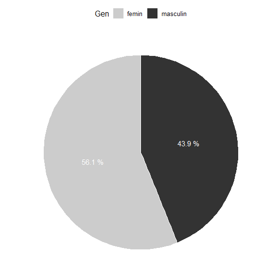

```r
## Pie chart
Data_merged_wide_all  %>%
  mutate(Gen = as.factor(as.character(Gen))) %>%
  mutate(Gen = forcats::fct_recode(Gen, "femin" = "f", "masculin" = "m")) %>%
  group_by(Gen) %>%
  dplyr::summarise(counts = n()) %>%
  mutate(prop = round(counts*100/sum(counts), 1),
         lab.ypos = cumsum(prop) - .5*prop,
         Percent = paste0(prop, " %")) %>%
  ggpubr::ggpie(x = "prop", label = "Percent",
                fill = "Gen", color = "white",
                lab.pos = "in", lab.font = list(color = "white"),
                palette = "grey")
```

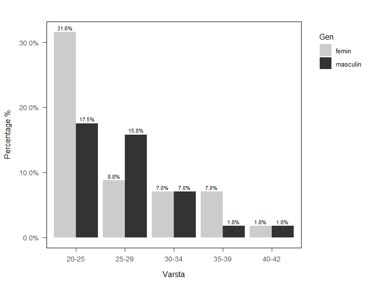

```r
## Dodged Bar plot of Age and Gender
Data_merged_wide_all %>%
  mutate(Varsta = as.numeric(as.character(Varsta))) %>%
  mutate(Varta_categ = cut(Varsta,
                           breaks=c(-Inf, 25, 30, 35, 40, Inf),
                           labels=c("20-25","25-29","30-34", "35-39", "40-42"),
                           right = FALSE)) %>%
  mutate(Varsta = as.factor(Varsta),
         Gen = as.factor(as.character(Gen))) %>%
  mutate(Gen = forcats::fct_recode(Gen, "femin" = "f", "masculin" = "m")) %>%
  dplyr::count(Varta_categ, Gen, .drop = FALSE) %>%         # Group by, then count number in each group (dont drop 0 counts)
  mutate(pct = prop.table(n)) %>%                           # Calculate percent within each var
    ggplot(aes(x = Varta_categ, y = pct, fill = Gen, label = scales::percent(pct))) +
      geom_col(position = position_dodge(preserve = "single"), stat = "identity") +    # Don't drop zero count
      geom_text(position = position_dodge(width = .9),      # move to center of bars
                vjust = -0.5,                               # nudge above top of bar
                size = 3) +
      scale_y_continuous(labels = scales::percent) +
      ggtitle("") +
      xlab("Varsta") + ylab("Percentage %") +
      guides(fill = guide_legend(title = "Gen", ncol = 1)) +
      scale_fill_grey(start = 0.8, end = 0.2, na.value = "red", aesthetics = "fill") +
      theme(legend.position = "right", legend.direction = "vertical",
            legend.justification = c(0, 1), panel.border = element_rect(fill = NA, colour = "black"))
```

## 2.2 t test Varsta by Gen

```r
# Gen
Data_merged_wide_all  %>%
  mutate(Gen = as.factor(as.character(Gen))) %>%
  mutate(Gen = forcats::fct_recode(Gen, "femin" = "f", "masculin" = "m")) %>%
  group_by(Gen) %>%
  dplyr::summarise(counts = n())
```

| Gen | counts |
| --- | --- |
| femin | 32 |
| masculin | 25 |

```r
# varsta
Data_merged_wide_all %>%
  mutate(Gen = as.factor(as.character(Gen))) %>%
  mutate(Varsta = as.numeric(as.character(Varsta))) %>%
  tidystats::describe_data(Varsta, na.rm = TRUE)
```

| var | missing | n | M | SD | SE | min | max | range | median | mode | skew | kurtosis |
| --- | --- | --- | --- | --- | --- | --- | --- | --- | --- | --- | --- | --- |
| Varsta | 0 | 57 | 26.4386 | 5.952243 | 0.7883939 | 20 | 42 | 22 | 25 | 20 | 0.8602534 | 2.787694 |

```r
# varsta by Gen
Data_merged_wide_all %>%
  mutate(Varsta = as.numeric(as.character(Varsta))) %>%
  dplyr::group_by(Gen) %>%
  tidystats::describe_data(Varsta, na.rm = TRUE) %>%
  knitr::kable(caption = "Varsta by Gen", format = "pandoc", digits = 2)
```

Varsta by Gen

| var | Gen | missing | n | M | SD | SE | min | max | range | median | mode | skew | kurtosis |
| --- | --- | --- | --- | --- | --- | --- | --- | --- | --- | --- | --- | --- | --- |
| Varsta | f | 0 | 32 | 26.31 | 6.36 | 1.12 | 20 | 40 | 20 | 24 | 20 | 0.72 | 2.09 |
| Varsta | m | 0 | 25 | 26.60 | 5.51 | 1.10 | 20 | 42 | 22 | 25 | 23 | 1.16 | 4.21 |

```r
# t test varsta by Gen
Data_merged_wide_all %>%
  mutate(Varsta = as.numeric(as.character(Varsta))) %>%
  t.test(Varsta ~ Gen, data = .) %>%
  tidy()
```

| estimate | estimate1 | estimate2 | statistic | p.value | parameter | conf.low | conf.high | method | alternative |
| --- | --- | --- | --- | --- | --- | --- | --- | --- | --- |
| -0.2875 | 26.3125 | 26.6 | -0.1826242 | 0.8557721 | 54.37398 | -3.443226 | 2.868226 | Welch Two Sample t-test | two.sided |

# 3 Define Functions

```r
subchunkify <- function(g, fig_height=7, fig_width=5) {
  g_deparsed <- paste0(deparse(
    function() {g}
  ), collapse = '')

  sub_chunk <- paste0("
  `","``{r sub_chunk_", floor(runif(1) * 10000), ", fig.height=", fig_height, ", fig.width=", fig_width, ", echo=FALSE}",
  "\n(",
    g_deparsed
    , ")()",
  "\n`","``
  ")

  cat(knitr::knit(text = knitr::knit_expand(text = sub_chunk), quiet = TRUE))
}
```

```r
#~~~~~~~~~~~~~~~~~~~~~~~~~~~~~~~~~~~~~~~~~~~~~~~~~~~~~~~~~~~~~~~~~~~~~~~~~~~~~~~~~~~~~~~~~~~~~~~~~~~~~~~~~~~~~~~~~~~~~~~~~~~~~~~~~~~~~~~~~~
# Define Function for mining correlations
#~~~~~~~~~~~~~~~~~~~~~~~~~~~~~~~~~~~~~~~~~~~~~~~~~~~~~~~~~~~~~~~~~~~~~~~~~~~~~~~~~~~~~~~~~~~~~~~~~~~~~~~~~~~~~~~~~~~~~~~~~~~~~~~~~~~~~~~~~~
## Function for p-value significance -- both for func_ancova_multibox(), Get_Top_Relationships() and Correlations_With_One()
stars_signif <- function(pval) {
  stars = "ns"
  if(pval <= 0.001)
    stars = "***"
  if(pval > 0.001 & pval <= 0.01)
    stars = "**"
  if(pval > 0.01 & pval <= 0.05)
    stars = "*"
  if(pval > 0.05 & pval <= 0.1)
    stars = "."
  stars
}

## Function that returns correlations of all variables in descending order.
# Arg for threshold with default at .3 will keep only correlantions above .3 and below -.3. Also has threshhold for p-value.
Get_Top_Relationships <- function(data_set,
                                  correlation_abs_threshold=0.3,
                                  pvalue_threshold=0.05) {
  require(psych)
  require(dplyr)
  feature_names <- names(data_set)
  # strip var names to index for pair-wise identification
  names(data_set) <- seq(1:ncol(data_set))
  # calculate correlation and significance numbers
  cor_data_df <- psych::corr.test(data_set)
  # apply var names to correlation matrix over index
  rownames(cor_data_df$r) <- feature_names
  colnames(cor_data_df$r) <- feature_names
  # top cor and sig
  relationships_set <- cor_data_df$ci[,c('r','p')]
  # apply var names to data over index pairs
  relationships_set$feature_1 <- feature_names[as.numeric(sapply(strsplit(rownames(relationships_set), "-"), `[`, 1))]
  relationships_set$feature_2 <- feature_names[as.numeric(
    sapply(strsplit(rownames(relationships_set), "-"), `[`, 2))]
  relationships_set <- dplyr::select(relationships_set, feature_1, feature_2, r, p) %>% dplyr::rename(correlation = r, p.value = p)
  # return only the most insteresting relationships
  return(filter(relationships_set, abs(correlation) > correlation_abs_threshold &
                  p.value < pvalue_threshold) %>%
        arrange(p.value) %>%
        mutate(p.signif = sapply(p.value, function(x) stars_signif(x))))
}

## Function that returns all correlation between numeric variables and one specific variable
Correlations_With_One <- function(data_set,
                            variable,
                            correlation_abs_threshold=0.3,
                            pvalue_threshold=0.05) {
  require(psych)
  require(dplyr)
  # use all numeric columns only
  numeric_cols <- unlist(lapply(data_set, is.numeric))
  data_set <- data_set[, numeric_cols]
  # calculate correlation and significance numbers
  cor_data_df <- psych::corr.test(data_set[, names(data_set) != variable], data_set[, variable], minlength = 20, adjust="none")
  # top cor and sig
  relationships_set <- as.data.frame(cbind(cor_data_df$r, cor_data_df$p))     # same as  cor_data_df$ci[,c('r','p')]
  relationships_set <- tibble::rownames_to_column(relationships_set, "Variable")   # relationships_set$Variable <- rownames(relationships_set)
  colnames(relationships_set) <- c("Variable", "correlation", "p.value")
  # return only the most insteresting relationships
  cat("#### Correlations with ", variable, "\n")
  return(filter(relationships_set, abs(correlation) > correlation_abs_threshold &
                  p.value < pvalue_threshold) %>%
           arrange(p.value) %>%
           mutate(p.signif = sapply(p.value, function(x) stars_signif(x)))) %>%
           tibble::as.tibble()
}


## Function for ploting correlation data frames resulting from Get_Top_Relationships and Correlations_With_One()
func_dotplot_cor <- function(df){                                        # https://www.r-pkg.org/pkg/ggpubr
  dotplotcor_scale_fill <- function(...){                                # Fix colors to signif factor levels even if missing
    ggplot2:::manual_scale(
      'color',
      values = setNames(
        c("darkgreen", "green3", "lawngreen", "yellow", "red"),
        c("***", "**", "*", ".", "ns")),
      ...
    )
  }

  dtoplot_theme <-
    ggpubr::theme_pubr() +
    theme(axis.text.y = element_text(size = 10))

  if(!"Variable" %in% colnames(df)){                                             # in oder to work for both Get_Top_Relationships and Correlations_With_One()
  df <-
    df %>%
      unite(cor_between, c("feature_1", "feature_2"), sep = " X ")               # unite 2 columns to x name from plot
  }else df <- df %>% dplyr::rename(cor_between = Variable)                       # change Variable to x name from plot

  df %>%
    ggpubr::ggdotchart(x = "cor_between", y = "correlation",
                       color = "p.signif",                                       # Color by sig
                       #   palette = c("#00AFBB", "#E7B800", "#FC4E07"),         # Custom color palette
                       sorting = "descending",                                   # Sort value in descending order
                       add = "segments",                                         # Add segments from y = 0 to dots
                       add.params = list(color = "lightgray", size = 2),         # Change segment color and size
                       group = "p.signif",                                       # Order by groups
                       dot.size = 8,                                             # Large dot size
                       xlab = "",
                       rotate = TRUE,                                            # Rotate vertically
                       label = round(.$correlation, 1),                          # Add mpg values as dot labels
                       font.label = list(color = "white", size = 9,
                                         vjust = 0.5),                           # Adjust label parameters
                       ggtheme = dtoplot_theme) +                                # ggplot2 theme
    dotplotcor_scale_fill() +                                            # Fix colors to signif factor levels even if missing
    geom_hline(yintercept = 0, linetype = 2, color = "lightgray")
}
```

```r
#~~~~~~~~~~~~~~~~~~~~~~~~~~~~~~~~~~~~~~~~~~~~~~~~~~~~~~~~~~~~~~~~~~~~~~~~~~~~~~~~~~~~~~~~~~~~~~~~~~~~~~~~~~~~~~~~~~~~~~~~~~~~~~~~~~~~~~~~~~
# Define Function for Pre-Post Plots, t Change and ANCOVA Post
#~~~~~~~~~~~~~~~~~~~~~~~~~~~~~~~~~~~~~~~~~~~~~~~~~~~~~~~~~~~~~~~~~~~~~~~~~~~~~~~~~~~~~~~~~~~~~~~~~~~~~~~~~~~~~~~~~~~~~~~~~~~~~~~~~~~~~~~~~~
## Func t test si boxplot simplu
func_t_box <- function(df, ind, pre_var, post_var){
  df_modif <-
    df %>%
    select(ind, pre_var, post_var) %>%
    tidyr::drop_na() %>%
    gather(pre_var, post_var, key = "Cond", value = "value") %>%
    mutate_at(vars(c(1, 2)), list(~as.factor(.))) %>%
    mutate(Cond = factor(Cond, levels = c(pre_var, post_var)))

  stat_comp <- ggpubr::compare_means(value ~ Cond, data = df_modif, method = "t.test", paired = TRUE)

  stat_comp2 <-
    df_modif %>%
    do(tidy(t.test(.$value ~ .$Cond,
                   paired = TRUE,
                   data=.)))

  plot <-
    ggpubr::ggpaired(df_modif, x = "Cond", y = "value", id = ind,
                     color = "Cond", line.color = "gray", line.size = 0.4,
                     palette = c("#00AFBB", "#FC4E07"), legend = "none") +
      stat_summary(fun.data = mean_se,  colour = "darkred") +
      ggpubr::stat_compare_means(method = "t.test", paired = TRUE, label.x = as.numeric(df_modif$Cond)-0.4, label.y = max(df_modif$value)+0.5) +
      ggpubr::stat_compare_means(method = "t.test", paired = TRUE, label = "p.signif", comparisons = list(c(pre_var, post_var)))

  cat(paste0("#### ", pre_var, " ", post_var, "\n", "\n"))
  print(stat_comp)
  print(stat_comp2)
  print(plot)
}


func_ancova_multibox <- function(df, ind, pre_var_c1, post_var_c1, pre_var_c2, post_var_c2){

  diff_score_c1 <- paste0(post_var_c1, " - ", pre_var_c1)
  diff_score_c2 <- paste0(post_var_c2, " - ", pre_var_c2)

  ## Plots and p-values for t tests
  df_modif <-
    df %>%
    select(ind, pre_var_c1, post_var_c1, pre_var_c2, post_var_c2) %>%
    tidyr::drop_na() %>%
    gather(pre_var_c1, post_var_c1, pre_var_c2, post_var_c2, key = "Cond", value = "value") %>%
    mutate_at(vars(c(1, 2)), list(~as.factor(.))) %>%
    mutate(Cond = factor(Cond, levels = c(pre_var_c1, post_var_c1, pre_var_c2, post_var_c2)))

  stat_comp <- ggpubr::compare_means(value ~ Cond, data = df_modif, method = "t.test", paired = TRUE, p.adjust.method = "holm")

  plot <-
    ggpubr::ggpaired(df_modif, x = "Cond", y = "value", id = ind,
                     color = "Cond", line.color = "gray", line.size = 0.4,
                     palette = c("#00AFBB", "#FC4E07", "#00AFBB", "#FC4E07"), legend = "none") +
    stat_summary(fun.data = mean_se,  colour = "darkred") +
    ggpubr::stat_compare_means(method = "t.test", paired = TRUE, label = "p.signif",
                               label.y = c(max(df_modif$value) + 0.1*IQR(df_modif$value),
                                           max(df_modif$value) + 0.1*IQR(df_modif$value),
                                           seq(max(df_modif$value) + 0.3*IQR(df_modif$value),
                                               max(df_modif$value) + 0.9*IQR(df_modif$value), length.out = 4)),
                               comparisons = list(c(pre_var_c1, post_var_c1),
                                                  c(pre_var_c2, post_var_c2),
                                                  c(post_var_c1, pre_var_c2),
                                                  c(pre_var_c1, pre_var_c2),
                                                  c(post_var_c1, post_var_c2),
                                                  c(pre_var_c1, post_var_c2)))

  ## For ttestChange or ANCOVAChange - we do ttestChange (Post-Pre) here, but it isnt very important
  df_modif2 <-
    df %>%
    select(ind, pre_var_c1, post_var_c1, pre_var_c2, post_var_c2) %>%
    tidyr::drop_na()
  df_modif2[diff_score_c1] <- df_modif2[, post_var_c1] - df_modif2[, pre_var_c1]
  df_modif2[diff_score_c2] <- df_modif2[, post_var_c2] - df_modif2[, pre_var_c2]

  tChange <- t.test(df_modif2[, diff_score_c1], df_modif2[, diff_score_c2], paired = TRUE)

  ## For descriptives by 2 factors (PrePost and OglEcran)
  df_modif3 <-
    df %>%
    select(ind, pre_var_c1, post_var_c1, pre_var_c2, post_var_c2) %>%
    tidyr::drop_na() %>%
    gather(pre_var_c1, post_var_c1, pre_var_c2, post_var_c2, key = "Cond", value = "value") %>%
    mutate(PrePost = case_when(stringr::str_detect(.$"Cond", "pre|Pre") ~ "Pre",
                               stringr::str_detect(.$"Cond", "post|Post") ~ "Post",
                               TRUE ~ NA_character_),
           OglEcran = case_when(stringr::str_detect(.$"Cond", "ogl|OGL") ~ "OGL",
                              stringr::str_detect(.$"Cond", "ecran|ECRAN") ~ "ECRAN",
                              TRUE ~ NA_character_)) %>%
    mutate(PrePost = as.factor(PrePost),
           OglEcran = as.factor(OglEcran))

  ## For ANCOVAPost - this is what we use
  df_modif4 <-
    df_modif3 %>%
    select(-"Cond") %>%
    spread("PrePost", "value")

  ## Models (here we use ANCOVAPost)    # https://m-clark.github.io/docs/mixedModels/anovamixed.html#introduction
  full_ancovaPost <-                                          # this is better than using lm() and glht()
      jmv::ancova(
        formula = Post ~ Pre + OglEcran,
        data = df_modif4,
        homo = TRUE,
        ss = "3",
        postHoc = ~ OglEcran,
        postHocCorr = list("tukey"),
        effectSize = list("eta", "partEta")
      )

      # mod_ancovaPost <- lm(Post ~ Pre + OglEcran, data = df_modif4)            # this is a Covariate Second model
      # mod_ancovaPost_ss3 <- car::Anova(mod_ancovaPost, type = "III")         # Type III sums of squares; see Andy Fields 2012
      # postHocs <- multcomp::glht(mod_ancovaPost, linfct = multcomp::mcp(OglEcran = "Tukey"))  # differences between the adjusted means,
      # sum_postHocs <- summary(postHocs)                                               # use Tukey or Dunnett?s post hoc tests
      # conf_postHocs <- confint(postHocs)
  scatter <-                                                             # Check for homogeneity of regression slopes
    ggplot(df_modif4, aes(Pre, Post, colour = OglEcran)) +
    geom_point(aes(shape = OglEcran), size = 3) +
    geom_smooth(method = "lm", aes(fill = OglEcran), alpha = 0.1)


  ## Other Models that work for this date
  # mod_ancovaPost <- lm(post ~ pre + treat)      # exactly the same with aov(post ~ pre + treat)
  # summary(mod_ancovaPost)
  #
  # mod_anovaRM <- aov(score ~ treat*time + Error(id), dflong)
  # summary(mod_anovaRM)
  #
  # mod_lme <- lme4::lmer(score ~ treat*time + (1|id), data=dflong)
  # anova(lmeModel)

  ## Output
  print(plot)
  cat(paste0("#### ", pre_var_c1, " ", post_var_c1, " ", pre_var_c2, " ", post_var_c2, "\n", "\n"))

  cat("#### Descriptives")
  psych::describeBy(df_modif3[, "value"], list(df_modif3[, "PrePost"], df_modif3[, "OglEcran"]), mat = TRUE) %>%
    as.tibble() %>%
    print()
  cat("\n")

  print(stat_comp)
  cat("\n")

  cat("#### t Change")
  tidy(tChange) %>% print()
  cat("\n")

  cat("#### ANCOVA Post")
  cat("\n")
  cat("##### Homogeneity test")
  print(tibble::as.tibble(full_ancovaPost$assump$homo))
  cat("##### ANCOVA output")
  print(tibble::as.tibble(full_ancovaPost$main))
  # tidy(mod_ancovaPost) %>%
  #   mutate(p.signif = sapply(p.value, function(x) stars_signif(x))) %>%
  #   print()
  # cat("\n")
  cat("##### Post Hoc")
  print(tibble::as.tibble(full_ancovaPost$postHoc[[1]]))
  # tidy(sum_postHocs) %>%
  #   mutate(p.signif = sapply(p.value, function(x) stars_signif(x))) %>%
  #   print()
  cat("\n")
  cat("##### Homogeneity of regression slopes")
  subchunkify(plot(scatter), 5, 5)
}
```

# 4 Analyses

## 4.1 Simple before-after analyses with t test

```r
#~~~~~~~~~~~~~~~~~~~~~~~~~~~~~~~~~~~~~~~~~~~~~~~~~~~~~~~~~~~~~~~~~~~~~~~~~~~~~~~~~~~~~~~~~~~~~~~~~~~~~~~~~~~~~~~~~~~~~~~~~~~~~~~~~~~~~~~~~~
# Simple before-after analyses with t test
#~~~~~~~~~~~~~~~~~~~~~~~~~~~~~~~~~~~~~~~~~~~~~~~~~~~~~~~~~~~~~~~~~~~~~~~~~~~~~~~~~~~~~~~~~~~~~~~~~~~~~~~~~~~~~~~~~~~~~~~~~~~~~~~~~~~~~~~~~~
## OXT has 2 outliers: 19, 43
# func_t_box(Data_merged_wide, "ID", "OXT_Pre_OGL", "OXT_Post_OGL")          # outlier
# func_t_box(Data_merged_wide, "ID", "OXT_Pre_ECRAN", "OXT_Post_ECRAN")      # ns

Data_merged_wide %>%
  filter(!ID %in% c(19, 43)) %>%
  func_t_box("ID", "OXT_Pre_OGL", "OXT_Post_OGL")    # ns
```

#### 4.1.0.1 OXT_Pre_OGL OXT_Post_OGL

| .y. | group1 | group2 | p | p.adj | p.format | p.signif | method |
| --- | --- | --- | --- | --- | --- | --- | --- |
| value | OXT_Pre_OGL | OXT_Post_OGL | 0.4479009 | 0.45 | 0.45 | ns | T-test |

| estimate | statistic | p.value | parameter | conf.low | conf.high | method | alternative |
| --- | --- | --- | --- | --- | --- | --- | --- |
| -0.03730667 | -0.7650671 | 0.4479009 | 49 | -0.1352988 | 0.06068546 | Paired t-test | two.sided |

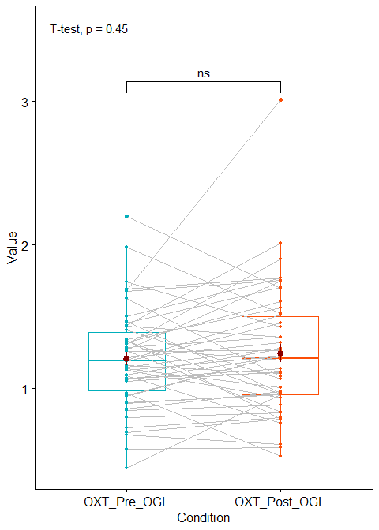

```r
Data_merged_wide %>%
  filter(!ID %in% c(19, 43)) %>%
  func_t_box("ID", "OXT_Pre_ECRAN", "OXT_Post_ECRAN")   # ns
```

#### 4.1.0.2 OXT_Pre_ECRAN OXT_Post_ECRAN

| .y. | group1 | group2 | p | p.adj | p.format | p.signif | method |
| --- | --- | --- | --- | --- | --- | --- | --- |
| value | OXT_Pre_ECRAN | OXT_Post_ECRAN | 0.09656358 | 0.097 | 0.097 | ns | T-test |

| estimate | statistic | p.value | parameter | conf.low | conf.high | method | alternative |
| --- | --- | --- | --- | --- | --- | --- | --- |
| -0.06776417 | -1.694261 | 0.09656358 | 49 | -0.1481397 | 0.01261141 | Paired t-test | two.sided |

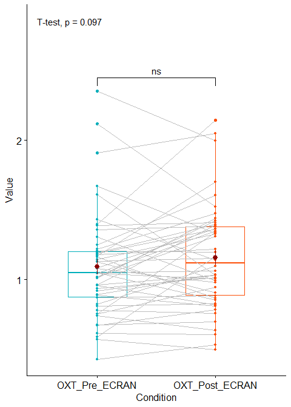

```r
func_t_box(Data_merged_wide, "ID", "Vas_Stres_Pre_OGL", "Vas_Stres_Post_OGL")         # sig
```

#### 4.1.0.3 Vas_Stres_Pre_OGL Vas_Stres_Post_OGL

| .y. | group1 | group2 | p | p.adj | p.format | p.signif | method |
| --- | --- | --- | --- | --- | --- | --- | --- |
| value | Vas_Stres_Pre_OGL | Vas_Stres_Post_OGL | 0.01603143 | 0.016 | 0.016 | * | T-test |

| estimate | statistic | p.value | parameter | conf.low | conf.high | method | alternative |
| --- | --- | --- | --- | --- | --- | --- | --- |
| 3.701754 | 2.483458 | 0.01603143 | 56 | 0.7157949 | 6.687714 | Paired t-test | two.sided |

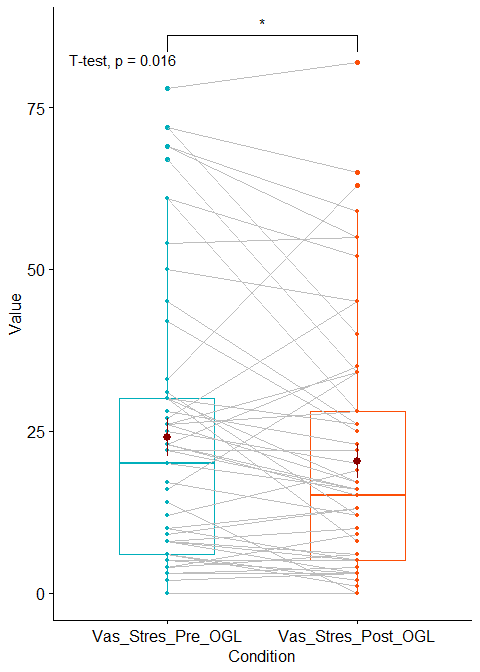

```r
func_t_box(Data_merged_wide, "ID", "Vas_Stres_Pre_ECRAN", "Vas_Stres_Post_ECRAN")     # sig la limita
```

#### 4.1.0.4 Vas_Stres_Pre_ECRAN Vas_Stres_Post_ECRAN

| .y. | group1 | group2 | p | p.adj | p.format | p.signif | method |
| --- | --- | --- | --- | --- | --- | --- | --- |
| value | Vas_Stres_Pre_ECRAN | Vas_Stres_Post_ECRAN | 0.04895545 | 0.049 | 0.049 | * | T-test |

| estimate | statistic | p.value | parameter | conf.low | conf.high | method | alternative |
| --- | --- | --- | --- | --- | --- | --- | --- |
| 2.678571 | 2.013594 | 0.04895545 | 55 | 0.01270213 | 5.344441 | Paired t-test | two.sided |

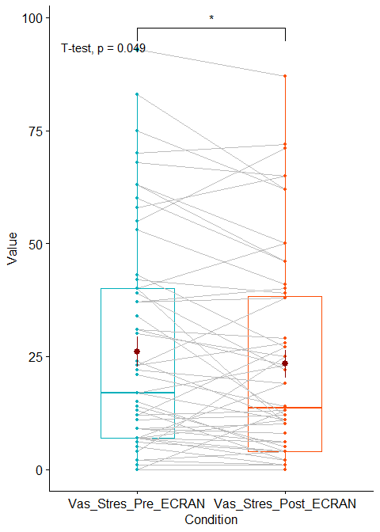

```r
func_t_box(Data_merged_wide, "ID", "Vas_Bine_Pre_OGL", "Vas_Bine_Post_OGL")           # ns
```

#### 4.1.0.5 Vas_Bine_Pre_OGL Vas_Bine_Post_OGL

| .y. | group1 | group2 | p | p.adj | p.format | p.signif | method |
| --- | --- | --- | --- | --- | --- | --- | --- |
| value | Vas_Bine_Pre_OGL | Vas_Bine_Post_OGL | 0.1552551 | 0.16 | 0.16 | ns | T-test |

| estimate | statistic | p.value | parameter | conf.low | conf.high | method | alternative |
| --- | --- | --- | --- | --- | --- | --- | --- |
| -2.385965 | -1.440638 | 0.1552551 | 56 | -5.703705 | 0.9317754 | Paired t-test | two.sided |

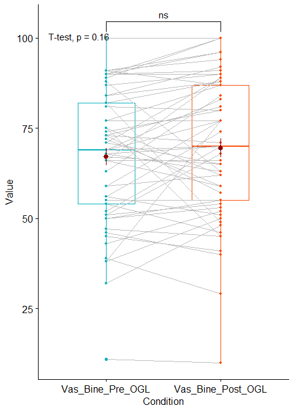

```r
func_t_box(Data_merged_wide, "ID", "Vas_Bine_Pre_ECRAN", "Vas_Bine_Post_ECRAN")       # ns
```

#### 4.1.0.6 Vas_Bine_Pre_ECRAN Vas_Bine_Post_ECRAN

| .y. | group1 | group2 | p | p.adj | p.format | p.signif | method |
| --- | --- | --- | --- | --- | --- | --- | --- |
| value | Vas_Bine_Pre_ECRAN | Vas_Bine_Post_ECRAN | 0.05420819 | 0.054 | 0.054 | ns | T-test |

| estimate | statistic | p.value | parameter | conf.low | conf.high | method | alternative |
| --- | --- | --- | --- | --- | --- | --- | --- |
| -2.642857 | -1.967235 | 0.05420819 | 55 | -5.335166 | 0.04945135 | Paired t-test | two.sided |

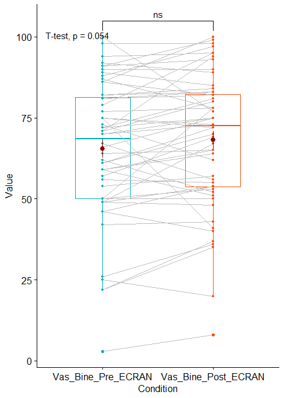

```r
func_t_box(Data_merged_wide, "ID", "IOS_Pre_OGL", "IOS_Post_OGL")                     # sig
```

#### 4.1.0.7 IOS_Pre_OGL IOS_Post_OGL

| .y. | group1 | group2 | p | p.adj | p.format | p.signif | method |
| --- | --- | --- | --- | --- | --- | --- | --- |
| value | IOS_Pre_OGL | IOS_Post_OGL | 0.0000004840492 | 0.00000048 | 0.00000048 | **** | T-test |

| estimate | statistic | p.value | parameter | conf.low | conf.high | method | alternative |
| --- | --- | --- | --- | --- | --- | --- | --- |
| -0.8596491 | -5.689274 | 0.0000004840492 | 56 | -1.162339 | -0.5569595 | Paired t-test | two.sided |

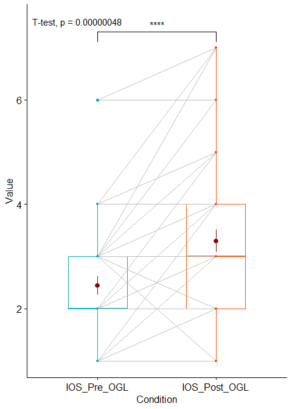

```r
func_t_box(Data_merged_wide, "ID", "IOS_Pre_ECRAN", "IOS_Post_ECRAN")                 # ns
```

#### 4.1.0.8 IOS_Pre_ECRAN IOS_Post_ECRAN

| .y. | group1 | group2 | p | p.adj | p.format | p.signif | method |
| --- | --- | --- | --- | --- | --- | --- | --- |
| value | IOS_Pre_ECRAN | IOS_Post_ECRAN | 0.7854353 | 0.79 | 0.79 | ns | T-test |

| estimate | statistic | p.value | parameter | conf.low | conf.high | method | alternative |
| --- | --- | --- | --- | --- | --- | --- | --- |
| -0.025 | -0.274125 | 0.7854353 | 39 | -0.2094679 | 0.1594679 | Paired t-test | two.sided |

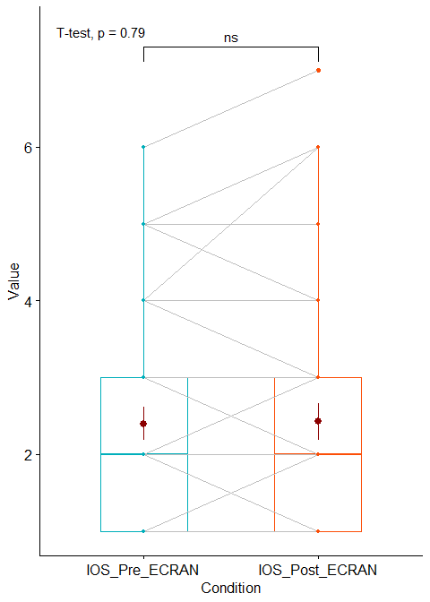

## 4.2 tChance and ANCOVAPost

```r
## tChance and ANCOVAPost

Data_merged_wide %>%
  filter(!ID %in% c(19, 43)) %>%
  func_ancova_multibox("ID", "OXT_Pre_OGL", "OXT_Post_OGL", "OXT_Pre_ECRAN", "OXT_Post_ECRAN")                                            # ns
```

#### 4.2.0.1 OXT_Pre_OGL OXT_Post_OGL OXT_Pre_ECRAN OXT_Post_ECRAN

#### 4.2.0.2 Descriptives

| item | group1 | group2 | vars | n | mean | sd | median | trimmed | mad | min | max | range | skew | kurtosis | se |
| --- | --- | --- | --- | --- | --- | --- | --- | --- | --- | --- | --- | --- | --- | --- | --- |
| 1 | Post | ECRAN | 1 | 50 | 1.158708 | 0.3677681 | 1.118380 | 1.136727 | 0.3710008 | 0.4974490 | 2.146657 | 1.649208 | 0.5724077 | 0.2101419 | 0.05201026 |
| 2 | Pre | ECRAN | 1 | 50 | 1.090944 | 0.3733437 | 1.047844 | 1.050052 | 0.2451350 | 0.4300217 | 2.352502 | 1.922480 | 1.1833843 | 1.9814288 | 0.05279877 |
| 3 | Post | OGL | 1 | 50 | 1.245014 | 0.4404577 | 1.211489 | 1.212607 | 0.3750559 | 0.5322802 | 3.009259 | 2.476979 | 1.2746514 | 3.1338630 | 0.06229012 |
| 4 | Pre | OGL | 1 | 50 | 1.207707 | 0.3457429 | 1.193350 | 1.198702 | 0.3289454 | 0.4504145 | 2.198205 | 1.747790 | 0.3613995 | 0.3536396 | 0.04889543 |

NA

| .y. | group1 | group2 | p | p.adj | p.format | p.signif | method |
| --- | --- | --- | --- | --- | --- | --- | --- |
| value | OXT_Pre_OGL | OXT_Post_OGL | 0.44790086 | 0.71 | 0.448 | ns | T-test |
| value | OXT_Pre_OGL | OXT_Pre_ECRAN | 0.05030480 | 0.25 | 0.050 | ns | T-test |
| value | OXT_Pre_OGL | OXT_Post_ECRAN | 0.35507929 | 0.71 | 0.355 | ns | T-test |
| value | OXT_Post_OGL | OXT_Pre_ECRAN | 0.02009282 | 0.12 | 0.020 | * | T-test |
| value | OXT_Post_OGL | OXT_Post_ECRAN | 0.18108270 | 0.54 | 0.181 | ns | T-test |
| value | OXT_Pre_ECRAN | OXT_Post_ECRAN | 0.09656358 | 0.39 | 0.097 | ns | T-test |

#### 4.2.0.3 t Change

| estimate | statistic | p.value | parameter | conf.low | conf.high | method | alternative |
| --- | --- | --- | --- | --- | --- | --- | --- |
| -0.0304575 | -0.4518243 | 0.6533893 | 49 | -0.1659231 | 0.1050081 | Paired t-test | two.sided |

#### 4.2.0.4 ANCOVA Post

##### 4.2.0.4.1 Homogeneity test

| F | df1 | df2 | p |
| --- | --- | --- | --- |
| 0.500146 | 1 | 98 | 0.4811143 |

##### 4.2.0.4.2 ANCOVA output

| name | ss | df | ms | F | p | etaSq | etaSqP |
| --- | --- | --- | --- | --- | --- | --- | --- |
| Pre | 7.17042280125 | 1 | 7.17042280125 | 77.5990597479 | 0.0000000000000498426 | 0.444439995376 | 0.444441452663 |
| OglEcran | 0.00005290077 | 1 | 0.00005290077 | 0.0005724977 | 0.9809600518492743726 | 0.000003278917 | 0.000005902003 |
| Residuals | 8.96313710477 | 97 | 0.09240347531 | NA | NA | NA | NA |

##### 4.2.0.4.3 Post Hoc

| OglEcran1 | sep | OglEcran2 | md | se | df | t | ptukey |
| --- | --- | --- | --- | --- | --- | --- | --- |
| ECRAN | - | OGL | 0.001474068 | 0.0616071 | 97 | 0.02392692 | 0.9809601 |

##### 4.2.0.4.4 Homogeneity of regression slopes

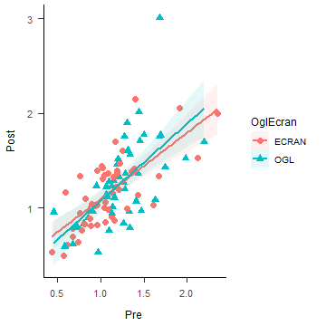

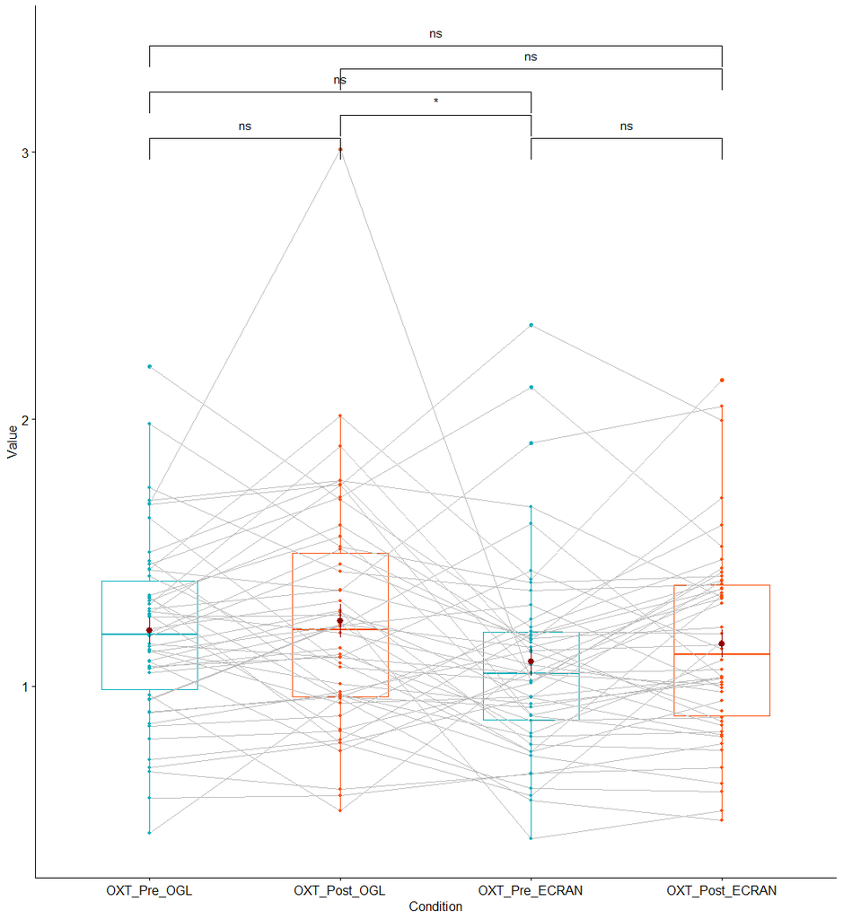

```r
func_ancova_multibox(Data_merged_wide, "ID", "Vas_Stres_Pre_OGL", "Vas_Stres_Post_OGL", "Vas_Stres_Pre_ECRAN", "Vas_Stres_Post_ECRAN")    # ns
```

#### 4.2.0.5 Vas_Stres_Pre_OGL Vas_Stres_Post_OGL Vas_Stres_Pre_ECRAN Vas_Stres_Post_ECRAN

#### 4.2.0.6 Descriptives

| item | group1 | group2 | vars | n | mean | sd | median | trimmed | mad | min | max | range | skew | kurtosis | se |
| --- | --- | --- | --- | --- | --- | --- | --- | --- | --- | --- | --- | --- | --- | --- | --- |
| 1 | Post | ECRAN | 1 | 56 | 23.35714 | 22.77832 | 13.5 | 20.60870 | 17.7912 | 0 | 87 | 87 | 0.9559258 | -0.1214280 | 3.043881 |
| 2 | Pre | ECRAN | 1 | 56 | 26.03571 | 24.59561 | 17.0 | 23.23913 | 21.4977 | 0 | 93 | 93 | 0.8984217 | -0.2426221 | 3.286727 |
| 3 | Post | OGL | 1 | 56 | 20.35714 | 20.09471 | 14.0 | 17.73913 | 16.3086 | 0 | 82 | 82 | 1.0999120 | 0.4064691 | 2.685269 |
| 4 | Pre | OGL | 1 | 56 | 23.89286 | 22.58856 | 18.5 | 21.26087 | 18.5325 | 0 | 78 | 78 | 0.9686043 | -0.2404931 | 3.018523 |

NA

| .y. | group1 | group2 | p | p.adj | p.format | p.signif | method |
| --- | --- | --- | --- | --- | --- | --- | --- |
| value | Vas_Stres_Pre_OGL | Vas_Stres_Post_OGL | 0.02268159 | 0.14 | 0.023 | * | T-test |
| value | Vas_Stres_Pre_OGL | Vas_Stres_Pre_ECRAN | 0.46848344 | 0.94 | 0.468 | ns | T-test |
| value | Vas_Stres_Pre_OGL | Vas_Stres_Post_ECRAN | 0.84980362 | 0.94 | 0.850 | ns | T-test |
| value | Vas_Stres_Post_OGL | Vas_Stres_Pre_ECRAN | 0.03121041 | 0.16 | 0.031 | * | T-test |
| value | Vas_Stres_Post_OGL | Vas_Stres_Post_ECRAN | 0.22023859 | 0.66 | 0.220 | ns | T-test |
| value | Vas_Stres_Pre_ECRAN | Vas_Stres_Post_ECRAN | 0.04895545 | 0.20 | 0.049 | * | T-test |

#### 4.2.0.7 t Change

| estimate | statistic | p.value | parameter | conf.low | conf.high | method | alternative |
| --- | --- | --- | --- | --- | --- | --- | --- |
| -0.8571429 | -0.4291491 | 0.6694911 | 55 | -4.859838 | 3.145552 | Paired t-test | two.sided |

#### 4.2.0.8 ANCOVA Post

##### 4.2.0.8.1 Homogeneity test

| F | df1 | df2 | p |
| --- | --- | --- | --- |
| 1.144693 | 1 | 110 | 0.2870049 |

##### 4.2.0.8.2 ANCOVA output

| name | ss | df | ms | F | p | etaSq | etaSqP |
| --- | --- | --- | --- | --- | --- | --- | --- |
| Pre | 40455.95675 | 1 | 40455.95675 | 428.552303 | 0.000000000000000000000000000000000000001452995 | 0.7965330913 | 0.797229033 |
| OglEcran | 44.33724 | 1 | 44.33724 | 0.469667 | 0.494595314136925590098314842180116102099418640 | 0.0008729513 | 0.004290385 |
| Residuals | 10289.75754 | 109 | 94.40145 | NA | NA | NA | NA |

##### 4.2.0.8.3 Post Hoc

| OglEcran1 | sep | OglEcran2 | md | se | df | t | ptukey |
| --- | --- | --- | --- | --- | --- | --- | --- |
| ECRAN | - | OGL | 1.259679 | 1.838083 | 109 | 0.6853225 | 0.4945953 |

##### 4.2.0.8.4 Homogeneity of regression slopes

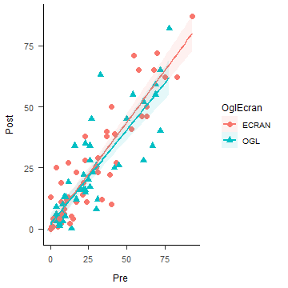

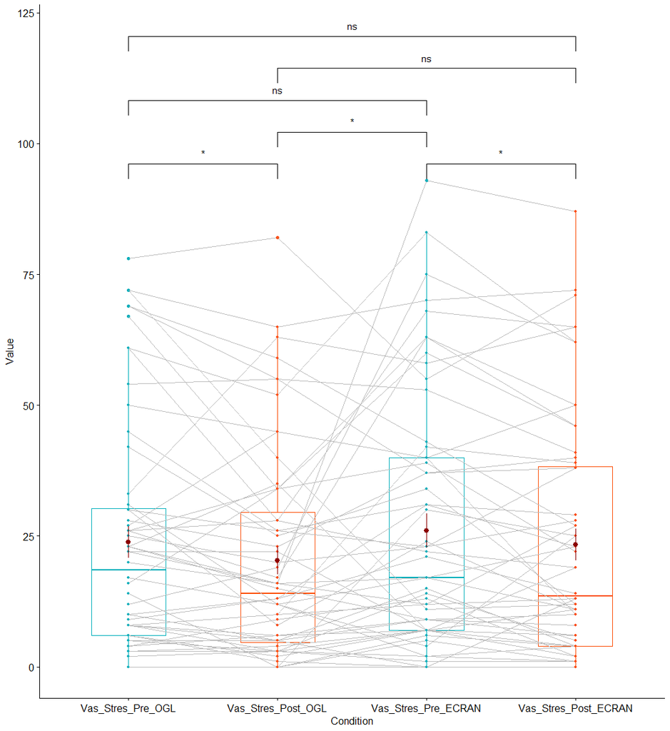

```r
func_ancova_multibox(Data_merged_wide, "ID", "Vas_Bine_Pre_OGL", "Vas_Bine_Post_OGL", "Vas_Bine_Pre_ECRAN", "Vas_Bine_Post_ECRAN")        # ns
```

#### 4.2.0.9 Vas_Bine_Pre_OGL Vas_Bine_Post_OGL Vas_Bine_Pre_ECRAN Vas_Bine_Post_ECRAN

#### 4.2.0.10 Descriptives

| item | group1 | group2 | vars | n | mean | sd | median | trimmed | mad | min | max | range | skew | kurtosis | se |
| --- | --- | --- | --- | --- | --- | --- | --- | --- | --- | --- | --- | --- | --- | --- | --- |
| 1 | Post | ECRAN | 1 | 56 | 68.14286 | 20.67271 | 72.5 | 69.36957 | 23.7216 | 8 | 100 | 92 | -0.5983049 | -0.06286085 | 2.762507 |
| 2 | Pre | ECRAN | 1 | 56 | 65.50000 | 21.03504 | 68.5 | 67.28261 | 20.7564 | 3 | 100 | 97 | -0.6830545 | 0.19204925 | 2.810925 |
| 3 | Post | OGL | 1 | 56 | 69.07143 | 19.64583 | 70.0 | 69.80435 | 24.4629 | 10 | 100 | 90 | -0.4363937 | -0.15847187 | 2.625284 |
| 4 | Pre | OGL | 1 | 56 | 66.78571 | 18.33597 | 69.0 | 67.80435 | 20.0151 | 11 | 100 | 89 | -0.5082226 | -0.04370438 | 2.450247 |

NA

| .y. | group1 | group2 | p | p.adj | p.format | p.signif | method |
| --- | --- | --- | --- | --- | --- | --- | --- |
| value | Vas_Bine_Pre_OGL | Vas_Bine_Post_OGL | 0.17995563 | 0.90 | 0.180 | ns | T-test |
| value | Vas_Bine_Pre_OGL | Vas_Bine_Pre_ECRAN | 0.64238579 | 1.00 | 0.642 | ns | T-test |
| value | Vas_Bine_Pre_OGL | Vas_Bine_Post_ECRAN | 0.59479975 | 1.00 | 0.595 | ns | T-test |
| value | Vas_Bine_Post_OGL | Vas_Bine_Pre_ECRAN | 0.20398876 | 0.90 | 0.204 | ns | T-test |
| value | Vas_Bine_Post_OGL | Vas_Bine_Post_ECRAN | 0.70215611 | 1.00 | 0.702 | ns | T-test |
| value | Vas_Bine_Pre_ECRAN | Vas_Bine_Post_ECRAN | 0.05420819 | 0.33 | 0.054 | ns | T-test |

#### 4.2.0.11 t Change

| estimate | statistic | p.value | parameter | conf.low | conf.high | method | alternative |
| --- | --- | --- | --- | --- | --- | --- | --- |
| -0.3571429 | -0.1808248 | 0.8571698 | 55 | -4.315285 | 3.600999 | Paired t-test | two.sided |

#### 4.2.0.12 ANCOVA Post

##### 4.2.0.12.1 Homogeneity test

| F | df1 | df2 | p |
| --- | --- | --- | --- |
| 0.07458959 | 1 | 110 | 0.78528 |

##### 4.2.0.12.2 ANCOVA output

| name | ss | df | ms | F | p | etaSq | etaSqP |
| --- | --- | --- | --- | --- | --- | --- | --- |
| Pre | 31344.5354417 | 1 | 31344.5354417 | 255.194590641 | 0.000000000000000000000000000002540241 | 0.70069658353 | 0.70070944819 |
| OglEcran | 0.8212817 | 1 | 0.8212817 | 0.006686545 | 0.934978547774482193766232285270234570 | 0.00001835948 | 0.00006134068 |
| Residuals | 13388.0359869 | 109 | 122.8260182 | NA | NA | NA | NA |

##### 4.2.0.12.3 Post Hoc

| OglEcran1 | sep | OglEcran2 | md | se | df | t | ptukey |
| --- | --- | --- | --- | --- | --- | --- | --- |
| ECRAN | - | OGL | 0.1713569 | 2.095563 | 109 | 0.0817713 | 0.9349785 |

##### 4.2.0.12.4 Homogeneity of regression slopes

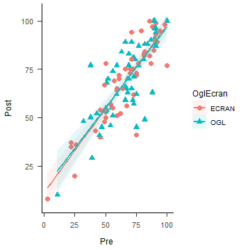

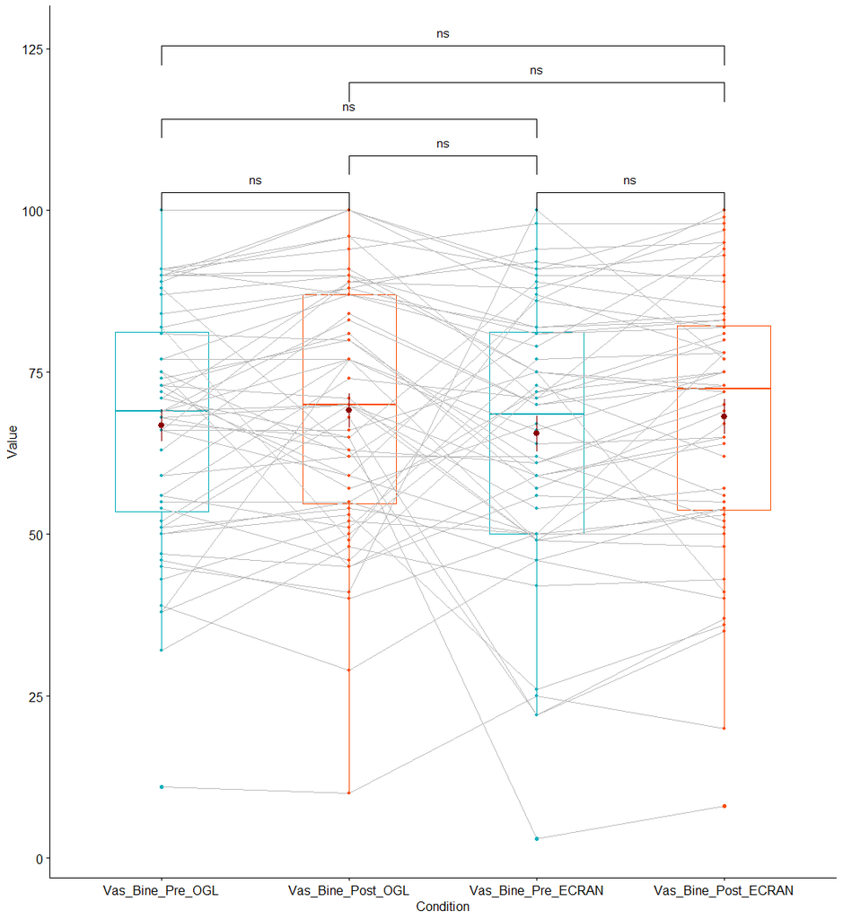

```r
func_ancova_multibox(Data_merged_wide, "ID", "IOS_Pre_OGL", "IOS_Post_OGL", "IOS_Pre_ECRAN", "IOS_Post_ECRAN")                            # sig
```

#### 4.2.0.13 IOS_Pre_OGL IOS_Post_OGL IOS_Pre_ECRAN IOS_Post_ECRAN

#### 4.2.0.14 Descriptives

| item | group1 | group2 | vars | n | mean | sd | median | trimmed | mad | min | max | range | skew | kurtosis | se |
| --- | --- | --- | --- | --- | --- | --- | --- | --- | --- | --- | --- | --- | --- | --- | --- |
| 1 | Post | ECRAN | 1 | 40 | 2.425 | 1.500214 | 2 | 2.15625 | 1.4826 | 1 | 7 | 6 | 1.3180756 | 1.30343004 | 0.2372046 |
| 2 | Pre | ECRAN | 1 | 40 | 2.400 | 1.335895 | 2 | 2.21875 | 1.4826 | 1 | 6 | 5 | 0.8380666 | -0.07766647 | 0.2112235 |
| 3 | Post | OGL | 1 | 40 | 3.325 | 1.745140 | 3 | 3.21875 | 1.4826 | 1 | 7 | 6 | 0.4695398 | -0.89353112 | 0.2759308 |
| 4 | Pre | OGL | 1 | 40 | 2.500 | 1.467599 | 2 | 2.25000 | 1.4826 | 1 | 6 | 5 | 1.1626134 | 0.59717793 | 0.2320477 |

NA

| .y. | group1 | group2 | p | p.adj | p.format | p.signif | method |
| --- | --- | --- | --- | --- | --- | --- | --- |
| value | IOS_Pre_OGL | IOS_Post_OGL | 0.00007117084 | 0.00043 | 0.000071 | **** | T-test |
| value | IOS_Pre_OGL | IOS_Pre_ECRAN | 0.69148878055 | 1.00000 | 0.6915 | ns | T-test |
| value | IOS_Pre_OGL | IOS_Post_ECRAN | 0.76492139210 | 1.00000 | 0.7649 | ns | T-test |
| value | IOS_Post_OGL | IOS_Pre_ECRAN | 0.00733747568 | 0.03700 | 0.0073 | ** | T-test |
| value | IOS_Post_OGL | IOS_Post_ECRAN | 0.00908390630 | 0.03700 | 0.0091 | ** | T-test |
| value | IOS_Pre_ECRAN | IOS_Post_ECRAN | 0.78543532979 | 1.00000 | 0.7854 | ns | T-test |

#### 4.2.0.15 t Change

| estimate | statistic | p.value | parameter | conf.low | conf.high | method | alternative |
| --- | --- | --- | --- | --- | --- | --- | --- |
| 0.8 | 3.820535 | 0.0004664486 | 39 | 0.3764592 | 1.223541 | Paired t-test | two.sided |

#### 4.2.0.16 ANCOVA Post

##### 4.2.0.16.1 Homogeneity test

| F | df1 | df2 | p |
| --- | --- | --- | --- |
| 3.044458 | 1 | 78 | 0.0849518 |

##### 4.2.0.16.2 ANCOVA output

| name | ss | df | ms | F | p | etaSq | etaSqP |
| --- | --- | --- | --- | --- | --- | --- | --- |
| Pre | 140.10996 | 1 | 140.1099609 | 162.37900 | 0.00000000000000000001185968 | 0.63838013 | 0.6783344 |
| OglEcran | 12.92732 | 1 | 12.9273211 | 14.98199 | 0.00022590404714710422481860 | 0.05890049 | 0.1628796 |
| Residuals | 66.44004 | 77 | 0.8628577 | NA | NA | NA | NA |

##### 4.2.0.16.3 Post Hoc

| OglEcran1 | sep | OglEcran2 | md | se | df | t | ptukey |
| --- | --- | --- | --- | --- | --- | --- | --- |
| ECRAN | - | OGL | -0.8044922 | 0.2078438 | 77 | -3.870657 | 0.000225904 |

##### 4.2.0.16.4 Homogeneity of regression slopes

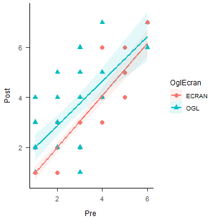

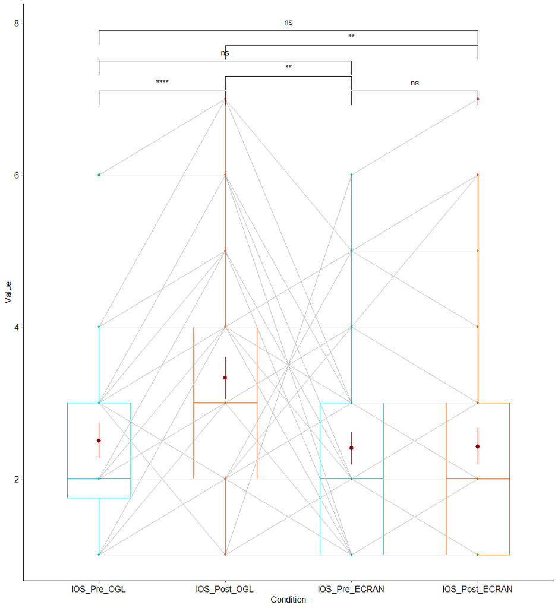

## 4.3 Same analyses by Gender

```r
# Females
cat("### Fem")
```

### 4.3.1 Fem

```r
Data_fem <-
  Data_merged_wide_all %>%
  filter(Gen != "m")

Data_fem %>%
  filter(!ID %in% c(19, 43)) %>%
  func_t_box("ID", "OXT_Pre_OGL", "OXT_Post_OGL")    # ns
```

#### 4.3.1.1 OXT_Pre_OGL OXT_Post_OGL

| .y. | group1 | group2 | p | p.adj | p.format | p.signif | method |
| --- | --- | --- | --- | --- | --- | --- | --- |
| value | OXT_Pre_OGL | OXT_Post_OGL | 0.1151197 | 0.12 | 0.12 | ns | T-test |

| estimate | statistic | p.value | parameter | conf.low | conf.high | method | alternative |
| --- | --- | --- | --- | --- | --- | --- | --- |
| -0.1173952 | -1.630182 | 0.1151197 | 26 | -0.2654212 | 0.03063075 | Paired t-test | two.sided |

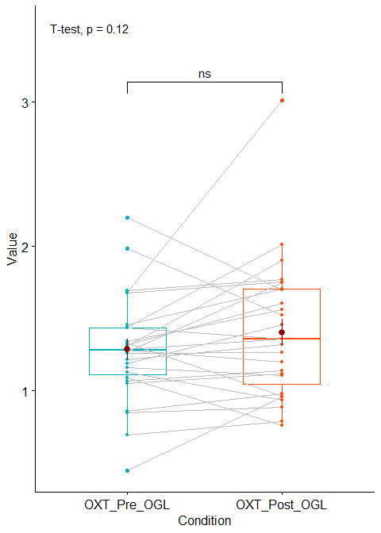

```r
Data_fem %>%
  filter(!ID %in% c(19, 43)) %>%
  func_t_box("ID", "OXT_Pre_ECRAN", "OXT_Post_ECRAN")   # ns
```

#### 4.3.1.2 OXT_Pre_ECRAN OXT_Post_ECRAN

| .y. | group1 | group2 | p | p.adj | p.format | p.signif | method |
| --- | --- | --- | --- | --- | --- | --- | --- |
| value | OXT_Pre_ECRAN | OXT_Post_ECRAN | 0.3914158 | 0.39 | 0.39 | ns | T-test |

| estimate | statistic | p.value | parameter | conf.low | conf.high | method | alternative |
| --- | --- | --- | --- | --- | --- | --- | --- |
| -0.0483537 | -0.8715783 | 0.3914158 | 26 | -0.162391 | 0.06568362 | Paired t-test | two.sided |

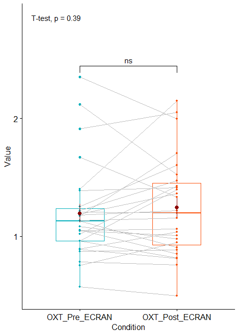

```r
func_t_box(Data_fem, "ID", "Vas_Stres_Pre_OGL", "Vas_Stres_Post_OGL")         # ns
```

#### 4.3.1.3 Vas_Stres_Pre_OGL Vas_Stres_Post_OGL

| .y. | group1 | group2 | p | p.adj | p.format | p.signif | method |
| --- | --- | --- | --- | --- | --- | --- | --- |
| value | Vas_Stres_Pre_OGL | Vas_Stres_Post_OGL | 0.05025007 | 0.05 | 0.05 | ns | T-test |

| estimate | statistic | p.value | parameter | conf.low | conf.high | method | alternative |
| --- | --- | --- | --- | --- | --- | --- | --- |
| 4.53125 | 2.03715 | 0.05025007 | 31 | -0.00525748 | 9.067757 | Paired t-test | two.sided |

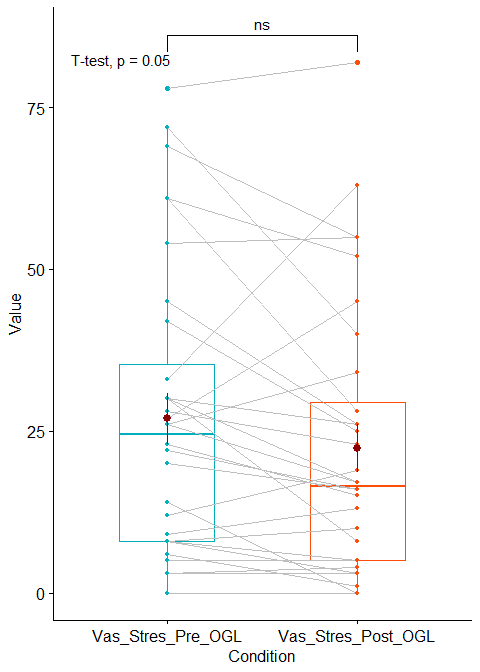

```r
func_t_box(Data_fem, "ID", "Vas_Stres_Pre_ECRAN", "Vas_Stres_Post_ECRAN")     # sig
```

#### 4.3.1.4 Vas_Stres_Pre_ECRAN Vas_Stres_Post_ECRAN

| .y. | group1 | group2 | p | p.adj | p.format | p.signif | method |
| --- | --- | --- | --- | --- | --- | --- | --- |
| value | Vas_Stres_Pre_ECRAN | Vas_Stres_Post_ECRAN | 0.03018603 | 0.03 | 0.03 | * | T-test |

| estimate | statistic | p.value | parameter | conf.low | conf.high | method | alternative |
| --- | --- | --- | --- | --- | --- | --- | --- |
| 4.225806 | 2.275481 | 0.03018603 | 30 | 0.4330926 | 8.01852 | Paired t-test | two.sided |

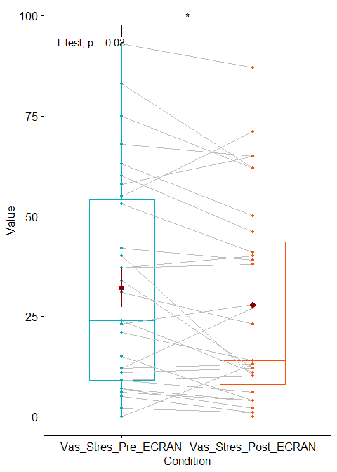

```r
func_t_box(Data_fem, "ID", "Vas_Bine_Pre_OGL", "Vas_Bine_Post_OGL")           # ns
```

#### 4.3.1.5 Vas_Bine_Pre_OGL Vas_Bine_Post_OGL

| .y. | group1 | group2 | p | p.adj | p.format | p.signif | method |
| --- | --- | --- | --- | --- | --- | --- | --- |
| value | Vas_Bine_Pre_OGL | Vas_Bine_Post_OGL | 0.3147139 | 0.31 | 0.31 | ns | T-test |

| estimate | statistic | p.value | parameter | conf.low | conf.high | method | alternative |
| --- | --- | --- | --- | --- | --- | --- | --- |
| -2.15625 | -1.02195 | 0.3147139 | 31 | -6.459495 | 2.146995 | Paired t-test | two.sided |

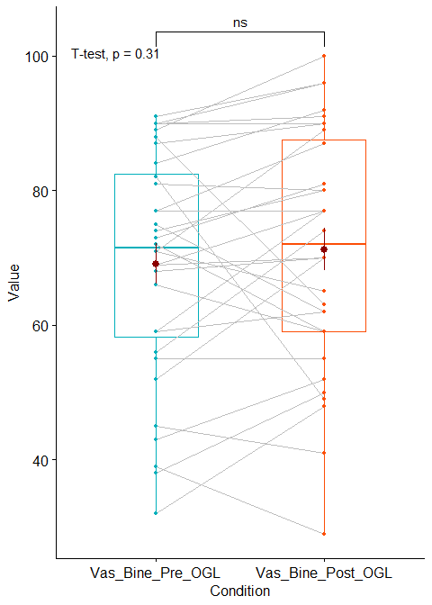

```r
func_t_box(Data_fem, "ID", "Vas_Bine_Pre_ECRAN", "Vas_Bine_Post_ECRAN")       # ns
```

#### 4.3.1.6 Vas_Bine_Pre_ECRAN Vas_Bine_Post_ECRAN

| .y. | group1 | group2 | p | p.adj | p.format | p.signif | method |
| --- | --- | --- | --- | --- | --- | --- | --- |
| value | Vas_Bine_Pre_ECRAN | Vas_Bine_Post_ECRAN | 0.2033291 | 0.2 | 0.2 | ns | T-test |

| estimate | statistic | p.value | parameter | conf.low | conf.high | method | alternative |
| --- | --- | --- | --- | --- | --- | --- | --- |
| -2.806452 | -1.300508 | 0.2033291 | 30 | -7.213605 | 1.600702 | Paired t-test | two.sided |

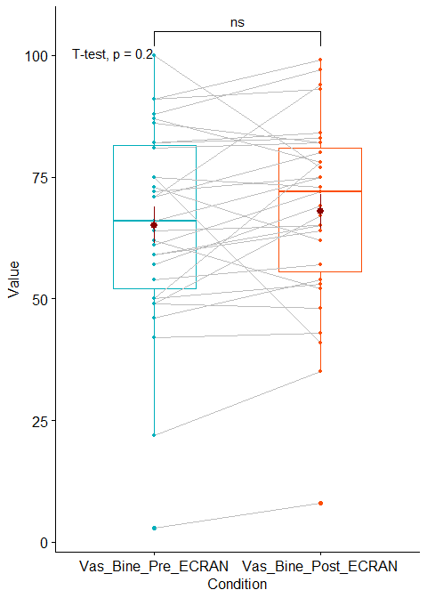

```r
func_t_box(Data_fem, "ID", "IOS_Pre_OGL", "IOS_Post_OGL")                     # sig
```

#### 4.3.1.7 IOS_Pre_OGL IOS_Post_OGL

| .y. | group1 | group2 | p | p.adj | p.format | p.signif | method |
| --- | --- | --- | --- | --- | --- | --- | --- |
| value | IOS_Pre_OGL | IOS_Post_OGL | 0.00001475519 | 0.000015 | 0.000015 | **** | T-test |

| estimate | statistic | p.value | parameter | conf.low | conf.high | method | alternative |
| --- | --- | --- | --- | --- | --- | --- | --- |
| -0.8125 | -5.130949 | 0.00001475519 | 31 | -1.135463 | -0.4895374 | Paired t-test | two.sided |

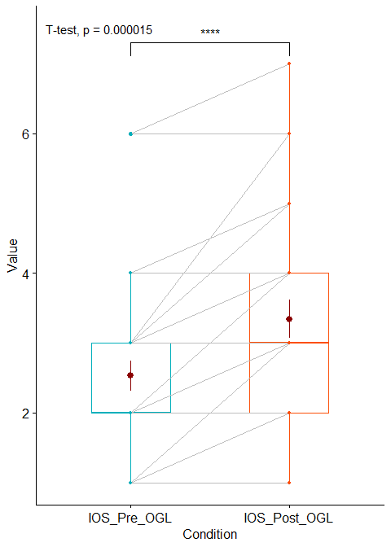

```r
func_t_box(Data_fem, "ID", "IOS_Pre_ECRAN", "IOS_Post_ECRAN")                 # ns
```

#### 4.3.1.8 IOS_Pre_ECRAN IOS_Post_ECRAN

| .y. | group1 | group2 | p | p.adj | p.format | p.signif | method |
| --- | --- | --- | --- | --- | --- | --- | --- |
| value | IOS_Pre_ECRAN | IOS_Post_ECRAN | 0.6651944 | 0.67 | 0.67 | ns | T-test |

| estimate | statistic | p.value | parameter | conf.low | conf.high | method | alternative |
| --- | --- | --- | --- | --- | --- | --- | --- |
| 0.04545455 | 0.4389311 | 0.6651944 | 21 | -0.1699047 | 0.2608138 | Paired t-test | two.sided |

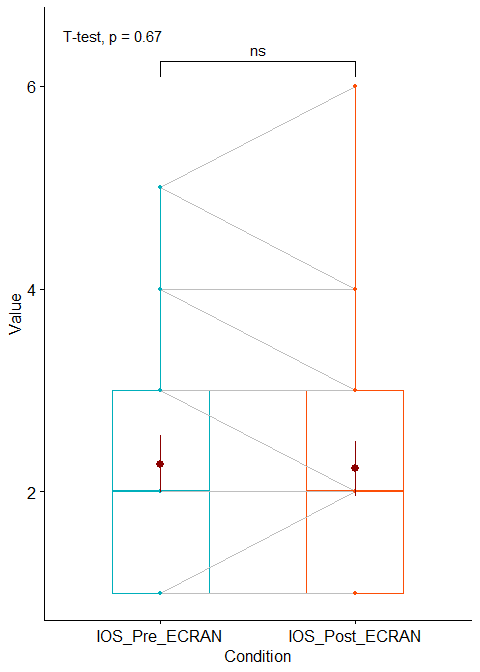

```r
# Males
cat("### Masc")
```

### 4.3.2 Masc

```r
Data_masc <-
  Data_merged_wide_all %>%
  filter(Gen != "f")

Data_masc %>%
  filter(!ID %in% c(19, 43)) %>%
  func_t_box("ID", "OXT_Pre_OGL", "OXT_Post_OGL")    # ns
```

#### 4.3.2.1 OXT_Pre_OGL OXT_Post_OGL

| .y. | group1 | group2 | p | p.adj | p.format | p.signif | method |
| --- | --- | --- | --- | --- | --- | --- | --- |
| value | OXT_Pre_OGL | OXT_Post_OGL | 0.3531429 | 0.35 | 0.35 | ns | T-test |

| estimate | statistic | p.value | parameter | conf.low | conf.high | method | alternative |
| --- | --- | --- | --- | --- | --- | --- | --- |
| 0.05671034 | 0.9485715 | 0.3531429 | 22 | -0.06727614 | 0.1806968 | Paired t-test | two.sided |

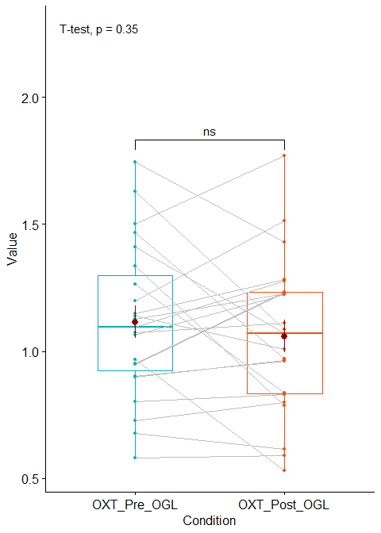

```r
Data_masc %>%
  filter(!ID %in% c(19, 43)) %>%
  func_t_box("ID", "OXT_Pre_ECRAN", "OXT_Post_ECRAN")   # ns
```

#### 4.3.2.2 OXT_Pre_ECRAN OXT_Post_ECRAN

| .y. | group1 | group2 | p | p.adj | p.format | p.signif | method |
| --- | --- | --- | --- | --- | --- | --- | --- |
| value | OXT_Pre_ECRAN | OXT_Post_ECRAN | 0.1364408 | 0.14 | 0.14 | ns | T-test |

| estimate | statistic | p.value | parameter | conf.low | conf.high | method | alternative |
| --- | --- | --- | --- | --- | --- | --- | --- |
| -0.09055037 | -1.545704 | 0.1364408 | 22 | -0.2120419 | 0.03094117 | Paired t-test | two.sided |

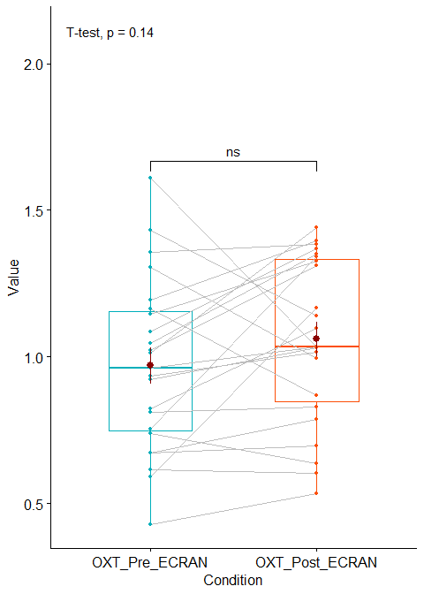

```r
func_t_box(Data_masc, "ID", "Vas_Stres_Pre_OGL", "Vas_Stres_Post_OGL")         # ns
```

#### 4.3.2.3 Vas_Stres_Pre_OGL Vas_Stres_Post_OGL

| .y. | group1 | group2 | p | p.adj | p.format | p.signif | method |
| --- | --- | --- | --- | --- | --- | --- | --- |
| value | Vas_Stres_Pre_OGL | Vas_Stres_Post_OGL | 0.1743285 | 0.17 | 0.17 | ns | T-test |

| estimate | statistic | p.value | parameter | conf.low | conf.high | method | alternative |
| --- | --- | --- | --- | --- | --- | --- | --- |
| 2.64 | 1.399931 | 0.1743285 | 24 | -1.252114 | 6.532114 | Paired t-test | two.sided |

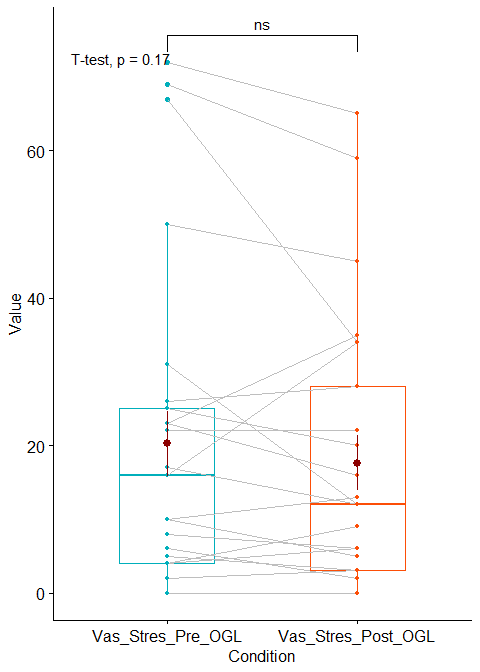

```r
func_t_box(Data_masc, "ID", "Vas_Stres_Pre_ECRAN", "Vas_Stres_Post_ECRAN")     # ns
```

#### 4.3.2.4 Vas_Stres_Pre_ECRAN Vas_Stres_Post_ECRAN

| .y. | group1 | group2 | p | p.adj | p.format | p.signif | method |
| --- | --- | --- | --- | --- | --- | --- | --- |
| value | Vas_Stres_Pre_ECRAN | Vas_Stres_Post_ECRAN | 0.6865116 | 0.69 | 0.69 | ns | T-test |

| estimate | statistic | p.value | parameter | conf.low | conf.high | method | alternative |
| --- | --- | --- | --- | --- | --- | --- | --- |
| 0.76 | 0.4085234 | 0.6865116 | 24 | -3.079591 | 4.599591 | Paired t-test | two.sided |

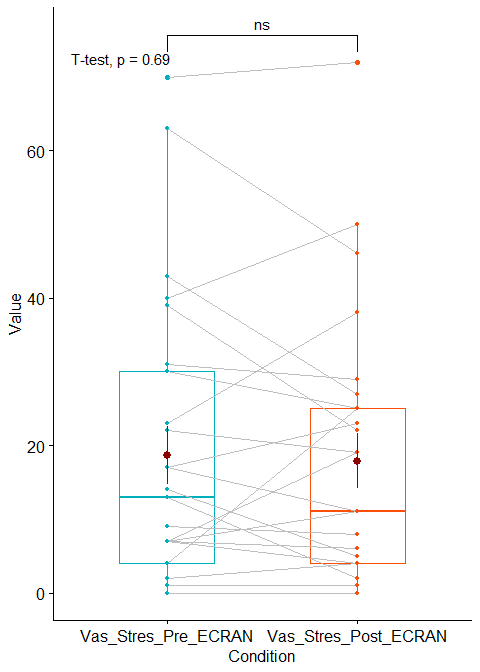

```r
func_t_box(Data_masc, "ID", "Vas_Bine_Pre_OGL", "Vas_Bine_Post_OGL")           # ns
```